# E-pox: Importing, cleaning and describing data

*Xanthi Andrianou, Gianfranco Spiteri (ECDC EI Group)*

# 1 Importing

## 1.1 Case-based data

```r
CB_Data0<-read.csv("input_data/E_pox_case_based_data.csv")

skimr::skim(CB_Data0)
```

Table 1.1: Data summary

| Name | CB_Data0 |
| --- | --- |
| Number of rows | 2000 |
| Number of columns | 13 |
| _______________________ |  |
| Column type frequency: |  |
| character | 12 |
| numeric | 1 |
| ________________________ |  |
| Group variables | None |

**Variable type: character**

| skim_variable | n_missing | complete_rate | min | max | empty | n_unique | whitespace |
| --- | --- | --- | --- | --- | --- | --- | --- |
| DateOfNotification | 0 | 1.00 | 10 | 10 | 0 | 179 | 0 |
| DateOfDiagnosis | 715 | 0.64 | 10 | 10 | 0 | 152 | 0 |
| DateOfOnset | 273 | 0.86 | 10 | 10 | 0 | 174 | 0 |
| Gender | 0 | 1.00 | 1 | 3 | 0 | 4 | 0 |
| SexualOrientation | 900 | 0.55 | 3 | 8 | 0 | 4 | 0 |
| Outcome | 0 | 1.00 | 1 | 3 | 0 | 2 | 0 |
| HIVStatus | 722 | 0.64 | 3 | 3 | 0 | 3 | 0 |
| Country | 0 | 1.00 | 8 | 8 | 0 | 5 | 0 |
| ClinicalSymptoms | 0 | 1.00 | 0 | 32 | 12 | 8 | 0 |
| Rash | 90 | 0.96 | 4 | 4 | 0 | 1 | 0 |
| SystemicSymptoms | 606 | 0.70 | 17 | 17 | 0 | 1 | 0 |
| Lesions | 973 | 0.51 | 7 | 7 | 0 | 1 | 0 |

**Variable type: numeric**

| skim_variable | n_missing | complete_rate | mean | sd | p0 | p25 | p50 | p75 | p100 | hist |
| --- | --- | --- | --- | --- | --- | --- | --- | --- | --- | --- |
| Age | 3 | 1 | 37.99 | 10.43 | 2 | 31 | 37 | 45 | 81 | ▁▆▇▂▁ |

```r
# Importing another file type (see ppt)
CB_Data0_json<-jsonlite::fromJSON("input_data/E_pox_case_based_data.json")

CB_Data0_xlsx<-readxl::read_excel(path = "input_data/E_pox_case_based_data.xlsx")
```

## 1.2 Aggregated data

```r
Agg_Data0<-read.csv("input_data/E_pox_aggregated_data.csv")

skimr::skim(CB_Data0)
```

Table 1.2: Data summary

| Name | CB_Data0 |
| --- | --- |
| Number of rows | 2000 |
| Number of columns | 13 |
| _______________________ |  |
| Column type frequency: |  |
| character | 12 |
| numeric | 1 |
| ________________________ |  |
| Group variables | None |

**Variable type: character**

| skim_variable | n_missing | complete_rate | min | max | empty | n_unique | whitespace |
| --- | --- | --- | --- | --- | --- | --- | --- |
| DateOfNotification | 0 | 1.00 | 10 | 10 | 0 | 179 | 0 |
| DateOfDiagnosis | 715 | 0.64 | 10 | 10 | 0 | 152 | 0 |
| DateOfOnset | 273 | 0.86 | 10 | 10 | 0 | 174 | 0 |
| Gender | 0 | 1.00 | 1 | 3 | 0 | 4 | 0 |
| SexualOrientation | 900 | 0.55 | 3 | 8 | 0 | 4 | 0 |
| Outcome | 0 | 1.00 | 1 | 3 | 0 | 2 | 0 |
| HIVStatus | 722 | 0.64 | 3 | 3 | 0 | 3 | 0 |
| Country | 0 | 1.00 | 8 | 8 | 0 | 5 | 0 |
| ClinicalSymptoms | 0 | 1.00 | 0 | 32 | 12 | 8 | 0 |
| Rash | 90 | 0.96 | 4 | 4 | 0 | 1 | 0 |
| SystemicSymptoms | 606 | 0.70 | 17 | 17 | 0 | 1 | 0 |
| Lesions | 973 | 0.51 | 7 | 7 | 0 | 1 | 0 |

**Variable type: numeric**

| skim_variable | n_missing | complete_rate | mean | sd | p0 | p25 | p50 | p75 | p100 | hist |
| --- | --- | --- | --- | --- | --- | --- | --- | --- | --- | --- |
| Age | 3 | 1 | 37.99 | 10.43 | 2 | 31 | 37 | 45 | 81 | ▁▆▇▂▁ |

```r
Agg_Data0_json<-jsonlite::fromJSON("input_data/E_pox_aggregated_data.json")


Agg_Data0_xlsx<-readxl::read_excel(path = "input_data/E_pox_aggregated_data.xlsx")

# Remove the files we do not need
# within rm() we ask for the objects containing
# the pattern "json" or "xlsx" to be removed from the environment
rm(list = ls(pattern = "json|xlsx"))
```

# 2 Cleaning

## 2.1 Case-based data

```r
# Start working using the CB_Data0 dataset

str(CB_Data0)
```

```
#> 'data.frame':    2000 obs. of  13 variables:
#>  $ DateOfNotification: chr  "2022-03-03" "2022-03-23" "2022-05-01" "2022-03-10" ...
#>  $ DateOfDiagnosis   : chr  "2022-03-02" "2022-03-23" "2022-05-01" NA ...
#>  $ DateOfOnset       : chr  "2022-02-27" "2022-03-13" "2022-04-19" "2022-02-27" ...
#>  $ Age               : int  39 46 49 45 41 37 40 36 27 36 ...
#>  $ Gender            : chr  "M" "M" "F" "M" ...
#>  $ SexualOrientation : chr  "MSM" NA NA NA ...
#>  $ Outcome           : chr  "A" "A" "UNK" "A" ...
#>  $ HIVStatus         : chr  "POS" "UNK" NA "NEG" ...
#>  $ Country           : chr  "CountryA" "CountryA" "CountryC" "CountryC" ...
#>  $ ClinicalSymptoms  : chr  "Rash" "Rash" "Rash, Systemic symptoms" "Rash, Systemic symptoms, Lesions" ...
#>  $ Rash              : chr  "Rash" "Rash" "Rash" "Rash" ...
#>  $ SystemicSymptoms  : chr  NA NA "Systemic symptoms" "Systemic symptoms" ...
#>  $ Lesions           : chr  NA NA NA "Lesions" ...
```

```r
summary(CB_Data0)
```

```
#>  DateOfNotification DateOfDiagnosis    DateOfOnset             Age
#>  Length:2000        Length:2000        Length:2000        Min.   : 2.00
#>  Class :character   Class :character   Class :character   1st Qu.:31.00
#>  Mode  :character   Mode  :character   Mode  :character   Median :37.00
#>                                                           Mean   :37.99
#>                                                           3rd Qu.:45.00
#>                                                           Max.   :81.00
#>                                                           NA's   :3
#>     Gender          SexualOrientation    Outcome           HIVStatus
#>  Length:2000        Length:2000        Length:2000        Length:2000
#>  Class :character   Class :character   Class :character   Class :character
#>  Mode  :character   Mode  :character   Mode  :character   Mode  :character
#>
#>
#>
#>
#>    Country          ClinicalSymptoms       Rash           SystemicSymptoms
#>  Length:2000        Length:2000        Length:2000        Length:2000
#>  Class :character   Class :character   Class :character   Class :character
#>  Mode  :character   Mode  :character   Mode  :character   Mode  :character
#>
#>
#>
#>
#>    Lesions
#>  Length:2000
#>  Class :character
#>  Mode  :character
#>
#>
#>
#>
```

```r
head(CB_Data0)
```

```
#>   DateOfNotification DateOfDiagnosis DateOfOnset Age Gender SexualOrientation
#> 1         2022-03-03      2022-03-02  2022-02-27  39      M               MSM
#> 2         2022-03-23      2022-03-23  2022-03-13  46      M              <NA>
#> 3         2022-05-01      2022-05-01  2022-04-19  49      F              <NA>
#> 4         2022-03-10            <NA>  2022-02-27  45      M              <NA>
#> 5         2022-05-04      2022-05-04  2022-04-27  41      M              <NA>
#> 6         2022-03-09            <NA>  2022-03-06  37      M              <NA>
#>   Outcome HIVStatus  Country                 ClinicalSymptoms Rash
#> 1       A       POS CountryA                             Rash Rash
#> 2       A       UNK CountryA                             Rash Rash
#> 3     UNK      <NA> CountryC          Rash, Systemic symptoms Rash
#> 4       A       NEG CountryC Rash, Systemic symptoms, Lesions Rash
#> 5       A       NEG CountryA Rash, Systemic symptoms, Lesions Rash
#> 6       A       POS CountryC Rash, Systemic symptoms, Lesions Rash
#>    SystemicSymptoms Lesions
#> 1              <NA>    <NA>
#> 2              <NA>    <NA>
#> 3 Systemic symptoms    <NA>
#> 4 Systemic symptoms Lesions
#> 5 Systemic symptoms Lesions
#> 6 Systemic symptoms Lesions
```

```r
glimpse(CB_Data0)
```

```
#> Rows: 2,000
#> Columns: 13
#> $ DateOfNotification <chr> "2022-03-03", "2022-03-23", "2022-05-01", "2022-03-…
#> $ DateOfDiagnosis    <chr> "2022-03-02", "2022-03-23", "2022-05-01", NA, "2022…
#> $ DateOfOnset        <chr> "2022-02-27", "2022-03-13", "2022-04-19", "2022-02-…
#> $ Age                <int> 39, 46, 49, 45, 41, 37, 40, 36, 27, 36, 34, 38, 68,…
#> $ Gender             <chr> "M", "M", "F", "M", "M", "M", "F", "M", "M", "M", "…
#> $ SexualOrientation  <chr> "MSM", NA, NA, NA, NA, NA, "HETERO", "MSM", NA, NA,…
#> $ Outcome            <chr> "A", "A", "UNK", "A", "A", "A", "A", "A", "A", "UNK…
#> $ HIVStatus          <chr> "POS", "UNK", NA, "NEG", "NEG", "POS", "NEG", "POS"…
#> $ Country            <chr> "CountryA", "CountryA", "CountryC", "CountryC", "Co…
#> $ ClinicalSymptoms   <chr> "Rash", "Rash", "Rash, Systemic symptoms", "Rash, S…
#> $ Rash               <chr> "Rash", "Rash", "Rash", "Rash", "Rash", "Rash", "Ra…
#> $ SystemicSymptoms   <chr> NA, NA, "Systemic symptoms", "Systemic symptoms", "…
#> $ Lesions            <chr> NA, NA, NA, "Lesions", "Lesions", "Lesions", NA, NA…
```

```r
# Working on the date variables

CB_Data <- CB_Data0 %>%
  # convert one date variable
  mutate(DateOfNotification=ymd(DateOfNotification)) %>%
  # Convert the date variables to date
  mutate(across(starts_with("Date"),
                ~ ymd(.x))) %>%
  # Add a variable with the week
  mutate(WeekDate=floor_date(DateOfNotification, unit="week", week_start="Monday")) %>%
  mutate(
    Gender = case_when(
      Gender == "F" ~ "Female",
      Gender == "M" ~ "Male",
      Gender == "O" ~ "Other",
      Gender == "UNK" ~ "Unknown",
      .default = Gender
    )
  )


head(CB_Data)
```

```
#>   DateOfNotification DateOfDiagnosis DateOfOnset Age Gender SexualOrientation
#> 1         2022-03-03      2022-03-02  2022-02-27  39   Male               MSM
#> 2         2022-03-23      2022-03-23  2022-03-13  46   Male              <NA>
#> 3         2022-05-01      2022-05-01  2022-04-19  49 Female              <NA>
#> 4         2022-03-10            <NA>  2022-02-27  45   Male              <NA>
#> 5         2022-05-04      2022-05-04  2022-04-27  41   Male              <NA>
#> 6         2022-03-09            <NA>  2022-03-06  37   Male              <NA>
#>   Outcome HIVStatus  Country                 ClinicalSymptoms Rash
#> 1       A       POS CountryA                             Rash Rash
#> 2       A       UNK CountryA                             Rash Rash
#> 3     UNK      <NA> CountryC          Rash, Systemic symptoms Rash
#> 4       A       NEG CountryC Rash, Systemic symptoms, Lesions Rash
#> 5       A       NEG CountryA Rash, Systemic symptoms, Lesions Rash
#> 6       A       POS CountryC Rash, Systemic symptoms, Lesions Rash
#>    SystemicSymptoms Lesions   WeekDate
#> 1              <NA>    <NA> 2022-02-28
#> 2              <NA>    <NA> 2022-03-21
#> 3 Systemic symptoms    <NA> 2022-04-25
#> 4 Systemic symptoms Lesions 2022-03-07
#> 5 Systemic symptoms Lesions 2022-05-02
#> 6 Systemic symptoms Lesions 2022-03-07
```

```r
skimr::skim(CB_Data)
```

Table 2.1: Data summary

| Name | CB_Data |
| --- | --- |
| Number of rows | 2000 |
| Number of columns | 14 |
| _______________________ |  |
| Column type frequency: |  |
| character | 9 |
| Date | 4 |
| numeric | 1 |
| ________________________ |  |
| Group variables | None |

**Variable type: character**

| skim_variable | n_missing | complete_rate | min | max | empty | n_unique | whitespace |
| --- | --- | --- | --- | --- | --- | --- | --- |
| Gender | 0 | 1.00 | 4 | 7 | 0 | 4 | 0 |
| SexualOrientation | 900 | 0.55 | 3 | 8 | 0 | 4 | 0 |
| Outcome | 0 | 1.00 | 1 | 3 | 0 | 2 | 0 |
| HIVStatus | 722 | 0.64 | 3 | 3 | 0 | 3 | 0 |
| Country | 0 | 1.00 | 8 | 8 | 0 | 5 | 0 |
| ClinicalSymptoms | 0 | 1.00 | 0 | 32 | 12 | 8 | 0 |
| Rash | 90 | 0.96 | 4 | 4 | 0 | 1 | 0 |
| SystemicSymptoms | 606 | 0.70 | 17 | 17 | 0 | 1 | 0 |
| Lesions | 973 | 0.51 | 7 | 7 | 0 | 1 | 0 |

**Variable type: Date**

| skim_variable | n_missing | complete_rate | min | max | median | n_unique |
| --- | --- | --- | --- | --- | --- | --- |
| DateOfNotification | 0 | 1.00 | 2022-01-19 | 2022-08-24 | 2022-04-06 | 179 |
| DateOfDiagnosis | 715 | 0.64 | 2022-01-19 | 2022-08-17 | 2022-04-05 | 152 |
| DateOfOnset | 273 | 0.86 | 2022-01-12 | 2022-08-10 | 2022-03-28 | 174 |
| WeekDate | 0 | 1.00 | 2022-01-17 | 2022-08-22 | 2022-04-04 | 32 |

**Variable type: numeric**

| skim_variable | n_missing | complete_rate | mean | sd | p0 | p25 | p50 | p75 | p100 | hist |
| --- | --- | --- | --- | --- | --- | --- | --- | --- | --- | --- |
| Age | 3 | 1 | 37.99 | 10.43 | 2 | 31 | 37 | 45 | 81 | ▁▆▇▂▁ |

```r
glimpse(CB_Data)
```

```
#> Rows: 2,000
#> Columns: 14
#> $ DateOfNotification <date> 2022-03-03, 2022-03-23, 2022-05-01, 2022-03-10, 20…
#> $ DateOfDiagnosis    <date> 2022-03-02, 2022-03-23, 2022-05-01, NA, 2022-05-04…
#> $ DateOfOnset        <date> 2022-02-27, 2022-03-13, 2022-04-19, 2022-02-27, 20…
#> $ Age                <int> 39, 46, 49, 45, 41, 37, 40, 36, 27, 36, 34, 38, 68,…
#> $ Gender             <chr> "Male", "Male", "Female", "Male", "Male", "Male", "…
#> $ SexualOrientation  <chr> "MSM", NA, NA, NA, NA, NA, "HETERO", "MSM", NA, NA,…
#> $ Outcome            <chr> "A", "A", "UNK", "A", "A", "A", "A", "A", "A", "UNK…
#> $ HIVStatus          <chr> "POS", "UNK", NA, "NEG", "NEG", "POS", "NEG", "POS"…
#> $ Country            <chr> "CountryA", "CountryA", "CountryC", "CountryC", "Co…
#> $ ClinicalSymptoms   <chr> "Rash", "Rash", "Rash, Systemic symptoms", "Rash, S…
#> $ Rash               <chr> "Rash", "Rash", "Rash", "Rash", "Rash", "Rash", "Ra…
#> $ SystemicSymptoms   <chr> NA, NA, "Systemic symptoms", "Systemic symptoms", "…
#> $ Lesions            <chr> NA, NA, NA, "Lesions", "Lesions", "Lesions", NA, NA…
#> $ WeekDate           <date> 2022-02-28, 2022-03-21, 2022-04-25, 2022-03-07, 20…
```

```r
plot(CB_Data$DateOfNotification)
hist(CB_Data$DateOfDiagnosis, breaks="weeks")
hist(CB_Data$DateOfOnset, breaks="weeks")

skimr::skim(CB_Data)
```

Table 2.1: Data summary

| Name | CB_Data |
| --- | --- |
| Number of rows | 2000 |
| Number of columns | 14 |
| _______________________ |  |
| Column type frequency: |  |
| character | 9 |
| Date | 4 |
| numeric | 1 |
| ________________________ |  |
| Group variables | None |

**Variable type: character**

| skim_variable | n_missing | complete_rate | min | max | empty | n_unique | whitespace |
| --- | --- | --- | --- | --- | --- | --- | --- |
| Gender | 0 | 1.00 | 4 | 7 | 0 | 4 | 0 |
| SexualOrientation | 900 | 0.55 | 3 | 8 | 0 | 4 | 0 |
| Outcome | 0 | 1.00 | 1 | 3 | 0 | 2 | 0 |
| HIVStatus | 722 | 0.64 | 3 | 3 | 0 | 3 | 0 |
| Country | 0 | 1.00 | 8 | 8 | 0 | 5 | 0 |
| ClinicalSymptoms | 0 | 1.00 | 0 | 32 | 12 | 8 | 0 |
| Rash | 90 | 0.96 | 4 | 4 | 0 | 1 | 0 |
| SystemicSymptoms | 606 | 0.70 | 17 | 17 | 0 | 1 | 0 |
| Lesions | 973 | 0.51 | 7 | 7 | 0 | 1 | 0 |

**Variable type: Date**

| skim_variable | n_missing | complete_rate | min | max | median | n_unique |
| --- | --- | --- | --- | --- | --- | --- |
| DateOfNotification | 0 | 1.00 | 2022-01-19 | 2022-08-24 | 2022-04-06 | 179 |
| DateOfDiagnosis | 715 | 0.64 | 2022-01-19 | 2022-08-17 | 2022-04-05 | 152 |
| DateOfOnset | 273 | 0.86 | 2022-01-12 | 2022-08-10 | 2022-03-28 | 174 |
| WeekDate | 0 | 1.00 | 2022-01-17 | 2022-08-22 | 2022-04-04 | 32 |

**Variable type: numeric**

| skim_variable | n_missing | complete_rate | mean | sd | p0 | p25 | p50 | p75 | p100 | hist |
| --- | --- | --- | --- | --- | --- | --- | --- | --- | --- | --- |
| Age | 3 | 1 | 37.99 | 10.43 | 2 | 31 | 37 | 45 | 81 | ▁▆▇▂▁ |

```r
# Cross-tabulate the country info and the date of notification
janitor::tabyl(dat = CB_Data,
               WeekDate,
               Country)
```

```
#>    WeekDate CountryA CountryB CountryC CountryD CountryE
#>  2022-01-17        2        1        0        0        0
#>  2022-01-24        4        1        2        1        1
#>  2022-01-31        7       10        6        2        2
#>  2022-02-07        9       10        8        3        1
#>  2022-02-14       23        3       12        4        0
#>  2022-02-21       25       16       11        7        6
#>  2022-02-28       41       16       21       15       12
#>  2022-03-07       61       22       40       14        5
#>  2022-03-14       51       30       37       16        8
#>  2022-03-21       72       39       37       21       11
#>  2022-03-28       83       46       35       23        4
#>  2022-04-04       77       38       47       22       12
#>  2022-04-11       86       35       46       23        8
#>  2022-04-18       63       27       36       12        7
#>  2022-04-25       44       25       33       14       10
#>  2022-05-02       44       17       22       11        6
#>  2022-05-09       39       10       21        6        1
#>  2022-05-16       30       11       19        5        2
#>  2022-05-23       21        8        9        5        0
#>  2022-05-30       12        3        9        3        2
#>  2022-06-06        7        9        5        2        0
#>  2022-06-13        2        5        6        1        0
#>  2022-06-20        2        3        3        3        0
#>  2022-06-27        3        3        1        1        0
#>  2022-07-04        0        2        2        1        1
#>  2022-07-11        2        0        3        0        0
#>  2022-07-18        1        0        1        0        1
#>  2022-07-25        0        0        0        1        0
#>  2022-08-01        2        1        0        1        0
#>  2022-08-08        3        0        0        0        1
#>  2022-08-15        0        0        2        0        0
#>  2022-08-22        0        0        0        0        1
```

```r
# Cross-tabulate the country info and the gender variable
janitor::tabyl(dat = CB_Data,
               Gender,
               Country)
```

```
#>   Gender CountryA CountryB CountryC CountryD CountryE
#>   Female       15        8        9        4        0
#>     Male      800      382      463      213      102
#>    Other        0        0        1        0        0
#>  Unknown        1        1        1        0        0
```

## 2.2 Aggregated data

```r
# Working on the Agg_Data0 dataset

str(Agg_Data0)
```

```
#> 'data.frame':    101 obs. of  3 variables:
#>  $ DateRep: chr  "2022-01-17" "2022-01-24" "2022-01-31" "2022-02-07" ...
#>  $ Country: chr  "CountryA" "CountryA" "CountryA" "CountryA" ...
#>  $ Cases  : int  2 4 11 18 40 64 105 164 213 284 ...
```

```r
names(Agg_Data0)
```

```
#> [1] "DateRep" "Country" "Cases"
```

```r
summary(Agg_Data0)
```

```
#>    DateRep            Country              Cases
#>  Length:101         Length:101         Min.   :  1.0
#>  Class :character   Class :character   1st Qu.: 53.0
#>  Mode  :character   Mode  :character   Median :163.0
#>                                        Mean   :242.4
#>                                        3rd Qu.:370.0
#>                                        Max.   :786.0
```

```r
Agg_Data <- Agg_Data0 %>%
  # Convert the date variables to date
  mutate(across(.cols= starts_with("Date"),
                .fns = ~ ymd(.x))) %>%
  # Convert character columns to factors:
  mutate(across(.cols = where(is.character),
                .fns = ~ as.factor(.x))) %>%
  # Add a variable with the week
  mutate(WeekDate=floor_date(DateRep, unit="week", week_start="Monday"))

str(Agg_Data)
```

```
#> 'data.frame':    101 obs. of  4 variables:
#>  $ DateRep : Date, format: "2022-01-17" "2022-01-24" ...
#>  $ Country : Factor w/ 4 levels "CountryA","CountryB",..: 1 1 1 1 1 1 1 1 1 1 ...
#>  $ Cases   : int  2 4 11 18 40 64 105 164 213 284 ...
#>  $ WeekDate: Date, format: "2022-01-17" "2022-01-24" ...
```

```r
summary(Agg_Data)
```

```
#>     DateRep               Country       Cases          WeekDate
#>  Min.   :2022-01-17   CountryA:28   Min.   :  1.0   Min.   :2022-01-17
#>  1st Qu.:2022-03-07   CountryB:26   1st Qu.: 53.0   1st Qu.:2022-03-07
#>  Median :2022-04-18   CountryD:26   Median :163.0   Median :2022-04-18
#>  Mean   :2022-04-20   CountryE:21   Mean   :242.4   Mean   :2022-04-20
#>  3rd Qu.:2022-05-30                 3rd Qu.:370.0   3rd Qu.:2022-05-30
#>  Max.   :2022-08-22                 Max.   :786.0   Max.   :2022-08-22
```

```r
# nrow() used below gives the total number of rows in the dataset
```

# 3 Basic descriptives of the case-based data

Total number of cases: 2000

## 3.1 Summary of the characteristics of the cases (tables and graphs)

### 3.1.1 Summary by country

```r
CB_table <- CB_Data %>%
  # Select columns starting with "Date"
  select(Country) %>%
 # Create summary table (attention to handling of missing values)
  gtsummary::tbl_summary(missing = "ifany")
CB_table
```

| **Characteristic** | **N = 2,000**<sup>1</sup> |
| --- | --- |
| Country |  |
| CountryA | 816 (41%) |
| CountryB | 391 (20%) |
| CountryC | 474 (24%) |
| CountryD | 217 (11%) |
| CountryE | 102 (5.1%) |

<sup>1</sup> n (%)

### 3.1.2 Time

```r
# Checking the different variables

CB_table1 <- CB_Data %>%
  # Select columns starting with "Date"
  select(starts_with("Date")) %>%
 # Create summary table (attention to handling of missing values)
  gtsummary::tbl_summary(missing = "ifany")

CB_table1
```

| **Characteristic** | **N = 2,000**<sup>1</sup> |
| --- | --- |
| DateOfNotification | 2022-01-19 to 2022-08-24 |
| DateOfDiagnosis | 2022-01-19 to 2022-08-17 |
| Unknown | 715 |
| DateOfOnset | 2022-01-12 to 2022-08-10 |
| Unknown | 273 |

<sup>1</sup> Range

#### 3.1.2.1 Epicurves (overall and by country)

```r
# First we can nake an object to summarise the data we want to
# show on the epicurve
EpiCurve_object<- CB_Data %>%
  group_by(WeekDate) %>%
  summarise(n=n(), .groups = "drop")

head(EpiCurve_object)
```

```
#> # A tibble: 6 × 2
#>   WeekDate       n
#>   <date>     <int>
#> 1 2022-01-17     3
#> 2 2022-01-24     9
#> 3 2022-01-31    27
#> 4 2022-02-07    31
#> 5 2022-02-14    42
#> 6 2022-02-21    65
```

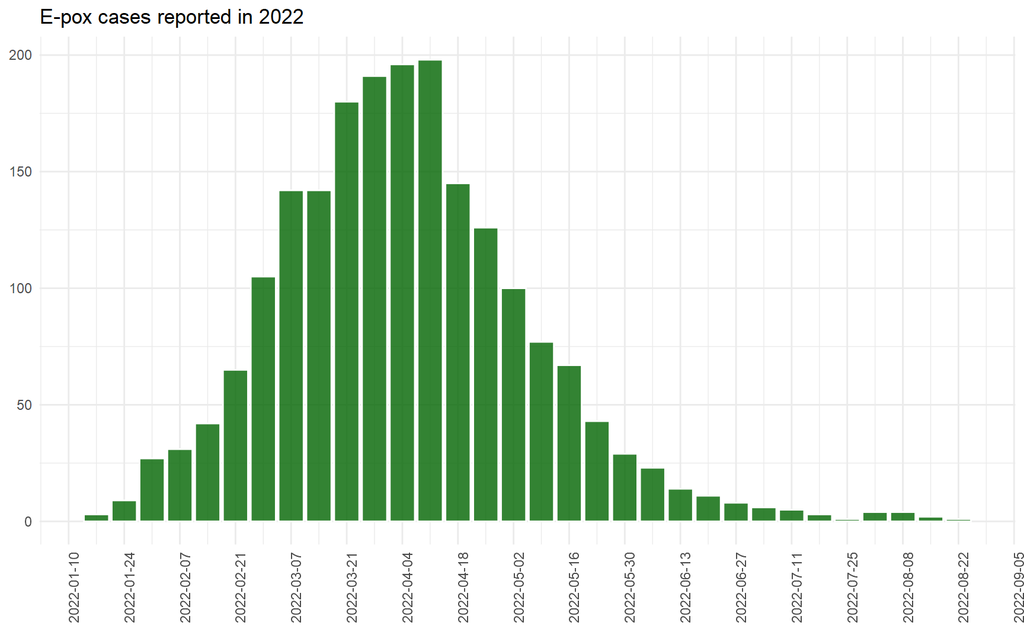

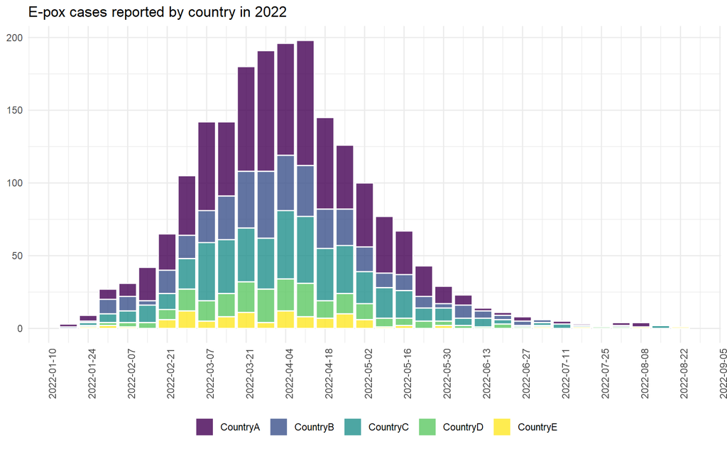

```r
EpiCurve <- EpiCurve_object %>%
  ggplot() +
  geom_col(aes(x = WeekDate, y = n), fill="darkgreen", color="white", alpha=0.8) +
  scale_fill_viridis_d() +
  scale_x_date(breaks = "2 weeks")+
  theme_minimal() +
  theme(legend.position = "bottom",
        axis.text = element_text(size=9),
        axis.title = element_blank(),
        axis.text.x = element_text(angle=90),
        legend.title = element_blank()) +
  labs(title="E-pox cases reported in 2022")

EpiCurve
```

#### 3.1.2.2 Plot the dates of onset, diagnosis, and notification

In the plots below, we use the dates of onset, diagnosis and notification and put them together to see whether there are difference and visualize the information to check if there are large delays. First, we try with dates and the plot is a messy (not easy to interpret.

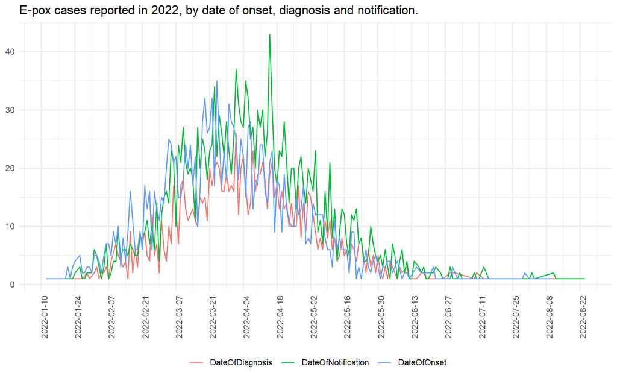

```r
plot_dates_object <- CB_Data %>%
  # use the variables of the dates and make a longer dataset
  # In the pivot_longer() command we select the columns which
  # we want to expand in long format and transform the dataset
  pivot_longer(
    # all columns starting with "DateOf..." will be taken
    cols=starts_with("DateOf"),
    # the names of the variables will be placed in a single column called "Indicator"
    names_to = "Indicator",
    # the values (which are dates in this case) will be placed in a
    # column called "Date
    values_to = "Date") %>%
  # group by date and indicator (type of date, i.e., onset, diagnosis or notification)
  group_by(Indicator, Date) %>%
  summarise(n=n(), .groups="drop") %>%
  # we add a filter to remove any rows where a date value might not exist
  filter(!is.na(Date))

# then we pass the object to the ggplot()
plot_dates <- plot_dates_object %>%
  ggplot() +
  geom_line(aes(x = Date, y = n, color=Indicator)) +
  scale_x_date(breaks = "2 weeks")+
  theme_minimal() +
  theme(legend.position = "bottom",
        axis.text = element_text(size=9),
        axis.title = element_blank(),
        axis.text.x = element_text(angle=90),
        legend.title = element_blank()) +
  labs(title="E-pox cases reported in 2022, by date of onset, diagnosis and notification.")

plot_dates
```

Then, we try to plot by week and there is some improvement in the visualization.

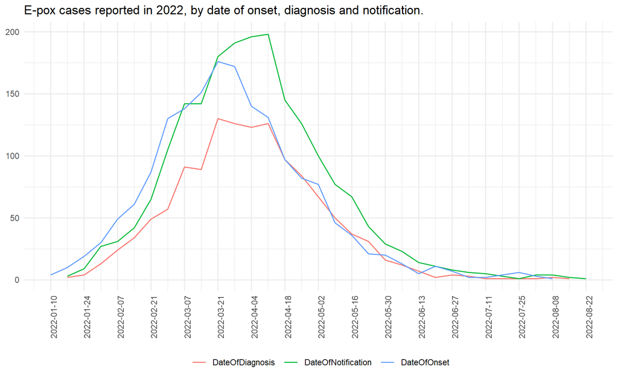

```r
plot_date_w<- CB_Data %>%
  # use the variables of the dates and make a longer dataset
  pivot_longer(cols=starts_with("DateOf"), names_to = "Indicator", values_to = "Date") %>%
  mutate(Date=floor_date(Date, unit="week", week_start="Monday")) %>%
  # group by date and indicator (type of date, i.e., onset, diagnosis or notification)
  group_by(Indicator, Date) %>%
  summarise(n=n(), .groups="drop") %>%
  filter(!is.na(Date)) %>%
  ggplot() +
  geom_line(aes(x = Date, y = n, color=Indicator)) +
  scale_x_date(breaks = "2 weeks")+
  theme_minimal() +
  theme(legend.position = "bottom",
        axis.text = element_text(size=9),
        axis.title = element_blank(),
        axis.text.x = element_text(angle=90),
        legend.title = element_blank()) +
  labs(title="E-pox cases reported in 2022, by date of onset, diagnosis and notification.")

plot_date_w
```

We can create the same graph by country (selecting only 2 countries).

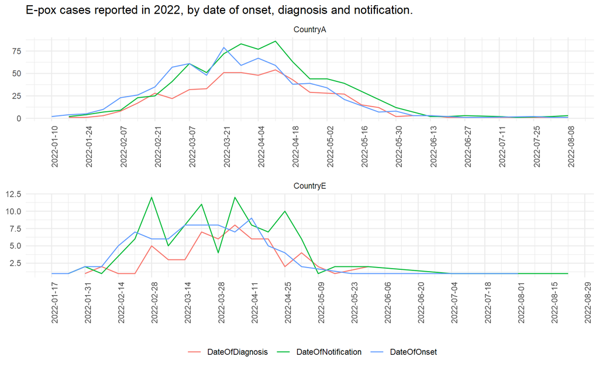

```r
plot_date_w_country<- CB_Data %>%
  filter(Country=="CountryA"|Country=="CountryE") %>%
  # use the variables of the dates and make a longer dataset
  pivot_longer(cols=starts_with("DateOf"), names_to = "Indicator", values_to = "Date") %>%
  mutate(Date=floor_date(Date, unit="week", week_start="Monday")) %>%
  # group by date and indicator (type of date, i.e., onset, diagnosis or notification)
  group_by(Country, Indicator, Date) %>%
  summarise(n=n(), .groups="drop") %>%
  filter(!is.na(Date)) %>%
  ggplot() +
  geom_line(aes(x = Date, y = n, color=Indicator)) +
  # in this line we indicate that a graph should be created
  # by country and that the axis should have different scales which
  # are adjusted by the range of values in each country
  facet_wrap(~Country, ncol = 1, scales = "free")+
  scale_x_date(breaks = "2 weeks")+
  theme_minimal() +
  theme(legend.position = "bottom",
        axis.text = element_text(size=9),
        axis.title = element_blank(),
        axis.text.x = element_text(angle=90),
        legend.title = element_blank()) +
  labs(title="E-pox cases reported in 2022, by date of onset, diagnosis and notification.")

plot_date_w_country
```

#### 3.1.2.3 Graph on cases reported by day and country

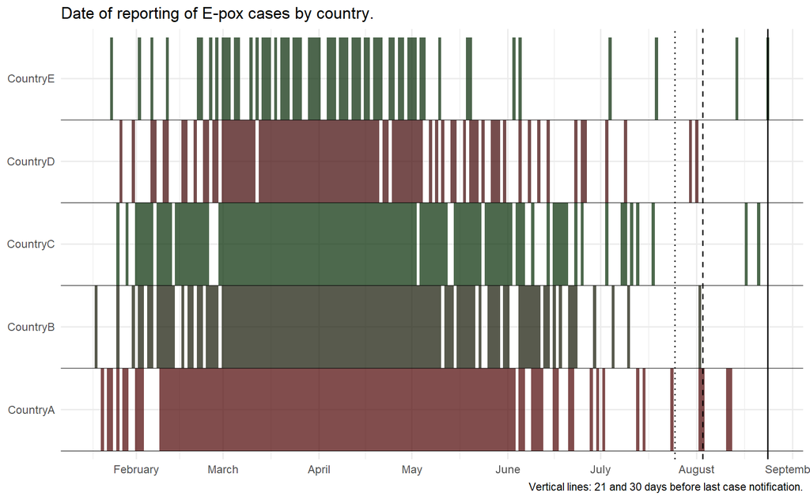

```r
hm_CB_Data<-CB_Data %>%
  distinct(DateOfNotification, Country) %>%
  mutate(n=1) %>%
  ungroup() %>%
  ggplot(.) +
  geom_tile(aes(x=DateOfNotification, y=as.factor(Country), fill = as.factor(Country)), alpha=0.7) +
  geom_hline(yintercept = seq(.5, nlevels(as.factor(CB_Data$Country)), 1), linewidth = .2) +
  geom_vline(xintercept = max(CB_Data$DateOfNotification, na.rm=T)-as.difftime(tim = 21, units = "days"), linetype=2) +
  geom_vline(xintercept = max(CB_Data$DateOfNotification, na.rm=T)-as.difftime(tim = 30, units = "days"), linetype=3) +
  geom_vline(xintercept = max(CB_Data$DateOfNotification, na.rm=T), linetype=1) +
  scale_fill_hue(l=4) +
  scale_x_date(date_breaks = "1 month", date_labels = "%B") +
  theme_minimal() +
  theme(legend.position = "none",
        axis.text = element_text(size=9),
        axis.title = element_blank()) +
  labs(caption="Vertical lines: 21 and 30 days before last case notification.",
       title="Date of reporting of E-pox cases by country.")

hm_CB_Data
```

### 3.1.3 Demographics

```r
CB_Data <- CB_Data %>%
  mutate(Age_cat=cut(Age,
                     breaks = c(0, 14, 17, 30, 40, 50, 60, 999),
                     include.lowest = T))

CB_demo <- CB_Data %>%
  # Select demographics and other columns
  select("Age_cat") %>%
 # Create summary table (attention to handling of missing values)
  gtsummary::tbl_summary(missing = "ifany")

CB_demo
```

| **Characteristic** | **N = 2,000**<sup>1</sup> |
| --- | --- |
| Age_cat |  |
| [0,14] | 3 (0.2%) |
| (14,17] | 13 (0.7%) |
| (17,30] | 479 (24%) |
| (30,40] | 779 (39%) |
| (40,50] | 474 (24%) |
| (50,60] | 192 (9.6%) |
| (60,999] | 57 (2.9%) |
| Unknown | 3 |

<sup>1</sup> n (%)

### 3.1.4 Clinical description

```r
clin_desc_table <- CB_Data %>%
  # Select demographics and other columns
  select("ClinicalSymptoms") %>%
 ## Create summary table (attention to handling of missing values)
  gtsummary::tbl_summary(missing = "ifany")

clin_desc_table
```

| **Characteristic** | **N = 2,000**<sup>1</sup> |
| --- | --- |
| ClinicalSymptoms |  |
|  | 12 (0.6%) |
| Lesions | 14 (0.7%) |
| Rash | 257 (13%) |
| Rash, Lesions | 323 (16%) |
| Rash, Systemic symptoms | 676 (34%) |
| Rash, Systemic symptoms, Lesions | 654 (33%) |
| Systemic symptoms | 28 (1.4%) |
| Systemic symptoms, Lesions | 36 (1.8%) |

<sup>1</sup> n (%)

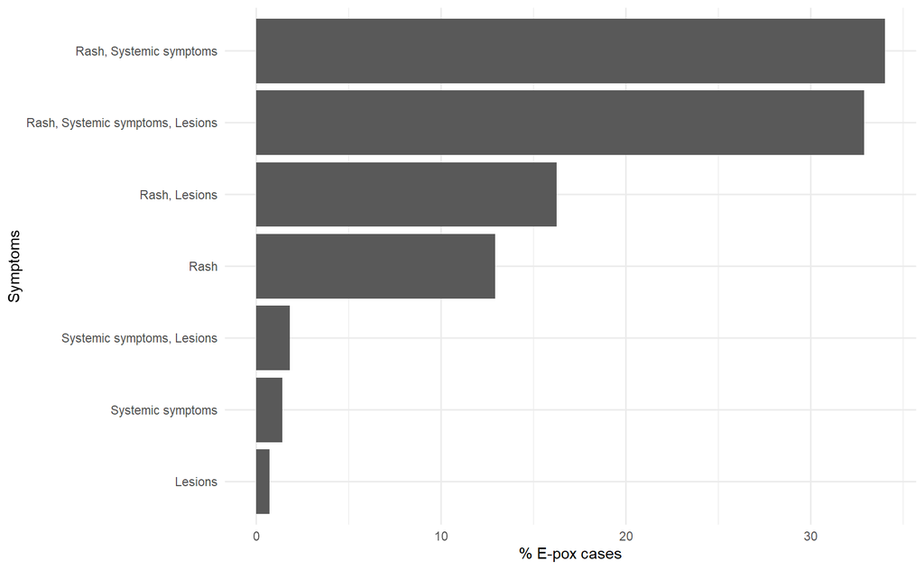

```r
clinical_desc <- CB_Data %>%
  filter(ClinicalSymptoms!="") %>%
  # Group by symptoms
  group_by(ClinicalSymptoms) %>%
  # Count for each symptom:
  summarise(count = n(), .groups="drop") %>%
  mutate(prop=(count/sum(count))*100) %>%
  # Create plot:
  ggplot(aes(
    # ordering the symptoms by count
    x = reorder(ClinicalSymptoms, desc(prop), decreasing = TRUE),
    y = prop)) +
  # Display bars as proportions
  geom_bar(stat = "identity") +
  #x axis label
  xlab("Symptoms") +
  #y axis label
  ylab("% E-pox cases") +
  # flip the axis
  coord_flip() +
  theme_minimal()

# Print plot:
clinical_desc
```

### 3.1.5 Outcome, HIV status

```r
Outcome_HIV <- CB_Data %>%
  # Select columns
  select("Outcome", "HIVStatus") %>%
  mutate(Outcome=case_when(Outcome=="UNK"~"Unknown",
                           Outcome=="A"~"Alive",
                           .default = Outcome))  %>%
  mutate(HIVStatus=case_when(HIVStatus=="POS"~"Positive",
                           HIVStatus=="NEG"~"Negative",
                           .default = HIVStatus)) %>%
 # Create summary table (attention to handling of missing values)
  gtsummary::tbl_summary(by = Outcome) %>%
  gtsummary::add_overall()
Outcome_HIV
```

| **Characteristic** | **Overall**, N = 2,000<sup>1</sup> | **Alive**, N = 1,405<sup>1</sup> | **Unknown**, N = 595<sup>1</sup> |
| --- | --- | --- | --- |
| HIVStatus |  |  |  |
| Negative | 525 (41%) | 513 (41%) | 12 (60%) |
| Positive | 307 (24%) | 304 (24%) | 3 (15%) |
| UNK | 446 (35%) | 441 (35%) | 5 (25%) |
| Unknown | 722 | 147 | 575 |

<sup>1</sup> n (%)

### 3.1.6 Sexual orientation

```r
sexorient <- CB_Data %>%
  filter(!is.na(SexualOrientation)) %>%
  # Select columns
  select("SexualOrientation") %>%
  gtsummary::tbl_summary()

sexorient <- CB_Data %>%
  filter(!is.na(SexualOrientation)) %>%
  # Select columns
  select("SexualOrientation") %>%
  mutate(SexualOrientation=case_when(SexualOrientation=="BISEXUAL"~"Bisexual",
                                     SexualOrientation=="HETERO"~"Heterosexual",
                                     SexualOrientation=="MSM"~"MSM/homo or bisexual male",
                                     SexualOrientation=="UNK"~"Unknown or undetermined",
                                     .default=SexualOrientation)) %>%
  gtsummary::tbl_summary()


sexorient
```

| **Characteristic** | **N = 1,100**<sup>1</sup> |
| --- | --- |
| SexualOrientation |  |
| Bisexual | 7 (0.6%) |
| Heterosexual | 46 (4.2%) |
| MSM/homo or bisexual male | 833 (76%) |
| Unknown or undetermined | 214 (19%) |

<sup>1</sup> n (%)

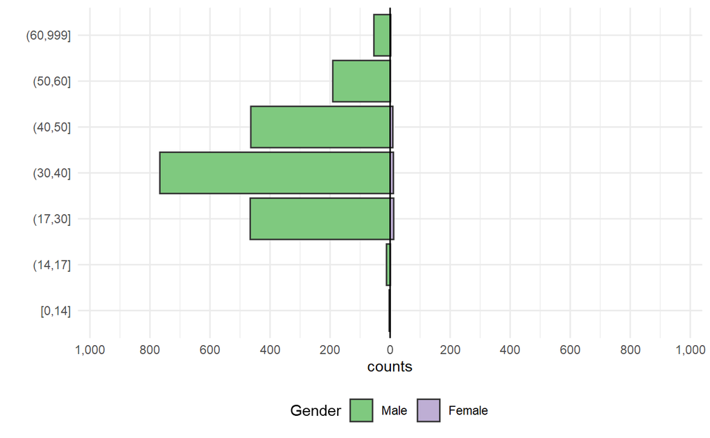

```r
# Optional - Creating the age and gender pyramid (first filtering out non M or F rows)
agegender_pyramid <- CB_Data %>%
  filter(Gender=="Female"|Gender=="Male" & !is.na(Age_cat)) %>%
  # Create age gender pyramid
  apyramid::age_pyramid(
  # Specify column containing age groups
  age_group = "Age_cat",
  # Splitting by Gender
  split_by = "Gender",
  # Don't show midpoint on the graph:
  show_midpoint = FALSE) +
  theme_minimal() +
  theme(legend.position = "bottom") +
  labs(x="")


agegender_pyramid
```

## 3.2 (Optional) Exploring trends and progress

In this part of the analysis we go beyond describing the basic information bue we are also checking how the trends of the reported cases might have changed. Therefore, we work with data reported before the last 3 weeks in which the data collected might be incomplete.

```r
week_xx <- paste0(format(as.Date(
  max(CB_Data$WeekDate) - as.difftime(tim = 3, units = "weeks")
), format = "%d/%m"),
"-",
format(as.Date(
  max(CB_Data$WeekDate) - as.difftime(tim = 15, units = "days")
),
format = "%d/%m"))
week_yy <-
  paste0(format(as.Date(
    max(CB_Data$WeekDate) - as.difftime(tim = 4, units = "weeks")
  ), format = "%d/%m"),
  "-",
  format(as.Date(
    max(CB_Data$WeekDate) - as.difftime(tim = 22, units = "days")
  ), format = "%d/%m"))

WeekCB_Data <- CB_Data %>%
  group_by(WeekDate) %>%
  summarise(n = n(), .groups="drop")

ltw <- WeekCB_Data %>%
  filter(
    WeekDate < max(CB_Data$WeekDate) - as.difftime(tim = 2, units = "weeks") &
      WeekDate >= max(CB_Data$WeekDate) - as.difftime(tim = 4, units = "weeks")
  ) %>%
  mutate(w_n = case_when(
    WeekDate == as.Date(max(CB_Data$WeekDate) - as.difftime(tim = 3, units = "weeks")) ~
      "current",
    WeekDate == as.Date(max(CB_Data$WeekDate) - as.difftime(tim = 4, units = "weeks")) ~
      "previous"
  ))


week_max <-
  paste0(format(as.Date(filter(
    WeekCB_Data, n == max(WeekCB_Data$n)
  )$WeekDate), format = "%d/%m"),
  "-",
  format(as.Date(
    filter(WeekCB_Data, n == max(WeekCB_Data$n))$WeekDate + as.difftime(tim = 6, units = "days")
  ), format = "%d/%m"))


# Days since last case

days_since_last_case <- CB_Data %>%
  group_by(Country) %>%
  summarise(days_last_report = as.integer(difftime(
    time1 = max(CB_Data$DateOfNotification, na.rm = T),
    time2 = max(DateOfNotification),
    units = "days"
  )), .groups="drop") %>%
  ungroup() %>%
  mutate(
    category = case_when(
      days_last_report <= 21 ~ "21 or less",
      days_last_report <= 30 ~ "22-30 days",
      days_last_report > 30 ~ "More than 30 days"
    )
  )


summary_days_since_last <- days_since_last_case %>%
  group_by(category) %>%
  summarise(n_countries = n(), .groups="drop") %>%
  adorn_totals()
```

There was a 300% change in the number of cases between 01/08-07/08 (2022-08-01, n=4) and 25/07-31/07 (2022-07-25, n=1).

The highest number of cases since the beginning of the outbreak was reported on 11/04-17/04 (2022-04-11, n=198).

- Change in the number of cases since the week with the max number of cases: -98% (difference: -194 cases)

Table 3.1: Number of countries and days since last case and until 2022-08-24

| category | n_countries |
| --- | --- |
| 21 or less | 3 |
| 22-30 days | 2 |
| Total | 5 |

Table 3.1: Number of countries and days since last case and until 2022-08-24 - complete table

| Country | days_last_report | category |
| --- | --- | --- |
| CountryA | 12 | 21 or less |
| CountryB | 22 | 22-30 days |
| CountryC | 3 | 21 or less |
| CountryD | 23 | 22-30 days |
| CountryE | 0 | 21 or less |

# 4 (Optional). Combine case-based and aggregated data and generate a summary of the information

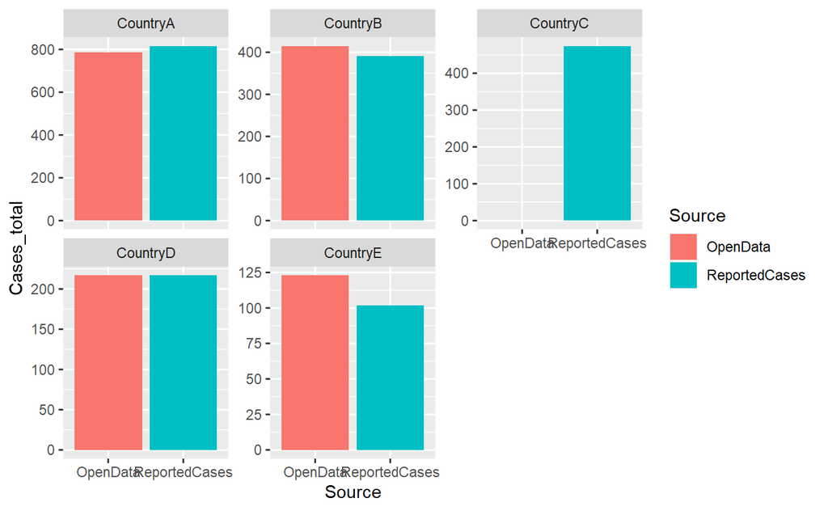

```r
# Get the weekly data and prepare them

# --- for the aggregated ones, add the new cases from the cumulative
Agg_Data_weekly <- Agg_Data %>%
  rename(Cases_total="Cases") %>%
  mutate(Source="OpenData") %>%
  group_by(Country)  %>%
  arrange(Country, DateRep) %>%
  # after arranging/sorting we have to subtract the previous cumulative
  # cases from the "current"
  # since for the first value this cannot happen we use the starting cumulative number
  mutate(Cases=Cases_total-lag(Cases_total)) %>%
  mutate(Cases=case_when(is.na(Cases)~Cases_total,
                             .default = Cases))


# --- for the case-based data we need to summarise and then add the cumulative number
CB_Data_weekly <- CB_Data %>%
  group_by(Country, WeekDate) %>%
  arrange(WeekDate) %>%
  summarise(Cases=n(), .groups="drop") %>%
  ungroup() %>%
  group_by(Country) %>%
  mutate(Cases_total=cumsum(Cases),
         Source="ReportedCases")


# Check the cumulative cases by week in case-based and aggregated data
# for the most recent week
Agg_Data_total <- Agg_Data_weekly %>%
  group_by(Country) %>%
  filter(WeekDate==max(WeekDate)) %>%
  select(c("Country", "Cases_total", "Cases", "Source"))


CB_Data_total <- CB_Data_weekly %>%
  group_by(Country) %>%
  filter(WeekDate==max(WeekDate)) %>%
  select(c("Country", "Cases_total", "Cases", "Source"))

# using the combined dataset we make it wide and check the difference between
# the case-based and the aggregated data
combined_df <- bind_rows(Agg_Data_total, CB_Data_total)

combined_df_wide <- combined_df %>%
  select(-Cases) %>%
  pivot_wider(id_cols = "Country",
              names_from = "Source", values_from = "Cases_total", values_fill = 0) %>%
  mutate(difference=OpenData-ReportedCases)

# we create a plot with the data by source and country to visualise the difference
comparison_plot = ggplot() +
    geom_col(data = combined_df, aes(x = Source, y = Cases_total, fill = Source)) +
    facet_wrap("Country", scales = "free_y")

comparison_plot

# select for which countries we will use the case-based data
cb_countries <- combined_df_wide %>%
  filter(OpenData <= ReportedCases) %>%
  pull(Country)


# Make a list of the countries for which case-based data were used
list_CB_countries <- paste(cb_countries, collapse = ", ")

# from the case based data we select only the countries we want and add them to the aggregated
cb_selected <- CB_Data_weekly %>%
  filter(Country %in% cb_countries) %>%
  select(Country, WeekDate, Cases_total, Cases, Source)

# From the aggregated data remove the countries we do not need
Agg_selected <- Agg_Data_weekly %>%
  filter(!Country %in% cb_countries) %>%
  select(Country, WeekDate, Cases_total, Cases, Source)

# Create the final dataset with the selected countries from each source
sum_db <- bind_rows(cb_selected, Agg_selected)
```

# 5 (Optional) Summary of the outbreak based on the both the case-based and aggregated data

```r
since_date<- glue("{day(max(sum_db$WeekDate)-weeks(3))} {month(max(sum_db$WeekDate)-weeks(3), label = T, abbr = F)} {year(max(sum_db$WeekDate)-weeks(3))}")
as_of_date<- glue("{day(max(sum_db$WeekDate))} {month(max(sum_db$WeekDate), label = T, abbr = F)} {year(max(sum_db$WeekDate))}")

# In last 4 weeks - since we use the weekly data
since_last_update <- sum_db %>%
  # taking the data of the last 4 weeks
  filter(WeekDate>=max(sum_db$WeekDate)-weeks(3)) %>%
  group_by(Country) %>%
  summarise(n=sum(Cases), .groups = "drop") %>%
  arrange(desc(n))

since_last_update_total <- sum(since_last_update$n)

since_last_update_sentence <- paste0(paste0(since_last_update$Country,
                                            " (", since_last_update$n, ")"),
                                     collapse = ", ") %>%
  stringi::stri_replace_last(fixed = ",", replacement = " and")
```

## 5.1 E-pox situation update, as of the week of 22 August 2022

### 5.1.1 Update

Since the last update on the week of 1 August 2022, and as of the week of 22 August 2022, 16 E-pox cases have been reported from 5 countries: CountryA (5), CountryE (5), CountryB (3), CountryC (2) and CountryD (1).

### 5.1.2 Summary

Since the start of the outbreak and as of 22 August 2022, 2045 E-pox cases have been reported from 5 countries: CountryA (816), CountryB (415), CountryC (474), CountryD (217) and CountryE (123).

### 5.1.3 Epicurve

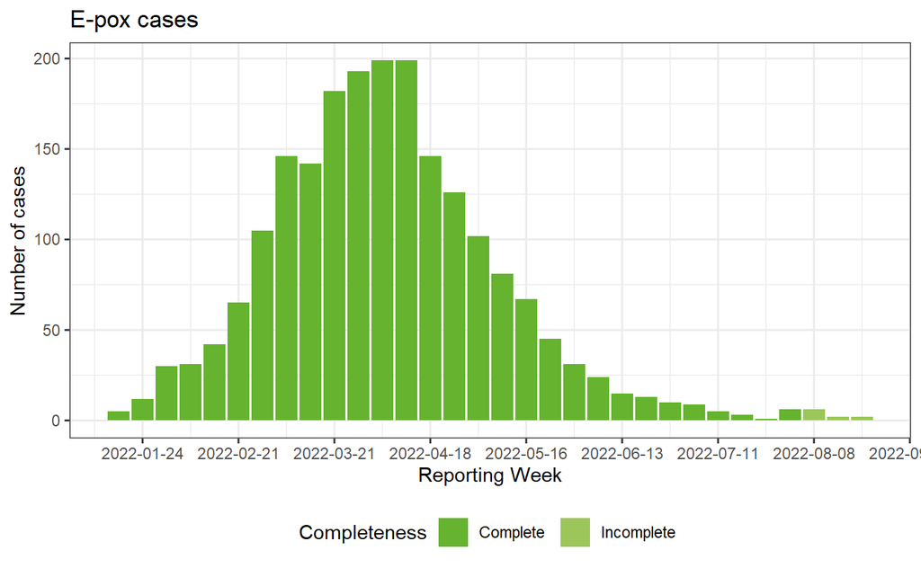

Disclaimer: The countries for which case-based data were used are the following: CountryA, CountryD, CountryC. For all other countries, data were collected from official, open sources.